# Statistic Related Plots

## Prerequisites

Make sure to be familiar with the following tutorials before proceeding:

- Terminology
- Extract Data

## 1. Introduction

Statistic related plots are indispensable in proper data analysis. `cypro` offers functions for all established plot types. This tutorial guides you through all of them and explains how their most important arguments work.

```r
# load packages
library(cypro)

# load object from broad institute compound profiling experiment week 4
# contains one time imaging data
object <- readRDS(file = "data/bids-week4.RDS")
```

## 2. Numeric variables

Statistical plotting functions that handle continuous numeric data variables are split in two sub groups.

1. Plots that allow for visualization of statistical tests. (Boxplot & Violinplot)
2. Plots that do not allow for visualization of statistical tests. (Histogram, Densityplot & Ridgeplot)

Throughout this section we visualize the differences in shape related data variables.

```r
# all area related variables
getStatVariableNames(object, starts_with("AreaShape"))
```

**output**

```
##  [1] "AreaShape_Area"                 "AreaShape_BoundingBoxArea"      "AreaShape_BoundingBoxMaximum_X"
##  [4] "AreaShape_BoundingBoxMaximum_Y" "AreaShape_BoundingBoxMinimum_X" "AreaShape_BoundingBoxMinimum_Y"
##  [7] "AreaShape_Center_X"             "AreaShape_Center_Y"             "AreaShape_Compactness"
## [10] "AreaShape_Eccentricity"         "AreaShape_EquivalentDiameter"   "AreaShape_EulerNumber"
## [13] "AreaShape_Extent"               "AreaShape_FormFactor"           "AreaShape_MajorAxisLength"
## [16] "AreaShape_MaxFeretDiameter"     "AreaShape_MaximumRadius"        "AreaShape_MeanRadius"
## [19] "AreaShape_MedianRadius"         "AreaShape_MinFeretDiameter"     "AreaShape_MinorAxisLength"
## [22] "AreaShape_Orientation"          "AreaShape_Perimeter"            "AreaShape_Solidity"
## [25] "AreaShape_Zernike_0_0"          "AreaShape_Zernike_1_1"          "AreaShape_Zernike_2_0"
## [28] "AreaShape_Zernike_2_2"          "AreaShape_Zernike_3_1"          "AreaShape_Zernike_3_3"
## [31] "AreaShape_Zernike_4_0"          "AreaShape_Zernike_4_2"          "AreaShape_Zernike_4_4"
## [34] "AreaShape_Zernike_5_1"          "AreaShape_Zernike_5_3"          "AreaShape_Zernike_5_5"
## [37] "AreaShape_Zernike_6_0"          "AreaShape_Zernike_6_2"          "AreaShape_Zernike_6_4"
## [40] "AreaShape_Zernike_6_6"          "AreaShape_Zernike_7_1"          "AreaShape_Zernike_7_3"
## [43] "AreaShape_Zernike_7_5"          "AreaShape_Zernike_7_7"          "AreaShape_Zernike_8_0"
## [46] "AreaShape_Zernike_8_2"          "AreaShape_Zernike_8_4"          "AreaShape_Zernike_8_6"
## [49] "AreaShape_Zernike_8_8"          "AreaShape_Zernike_9_1"          "AreaShape_Zernike_9_3"
## [52] "AreaShape_Zernike_9_5"          "AreaShape_Zernike_9_7"          "AreaShape_Zernike_9_9"
```

```r
# selected ones whose properties make sense to be compared against each other
vars_of_interest <-
  getStatVariableNames(object,
                       starts_with("AreaShape") &
                       contains(c("Max", "Min", "Mean", "Median", "Solidity", "Ecc")) &
                        -contains("Bounding")
                       )

vars_of_interest
```

**output**

```
## [1] "AreaShape_Eccentricity"     "AreaShape_MaxFeretDiameter" "AreaShape_MaximumRadius"    "AreaShape_MeanRadius"
## [5] "AreaShape_MedianRadius"     "AreaShape_MinFeretDiameter" "AreaShape_MinorAxisLength"  "AreaShape_Solidity"
```

### 2.1 Histograms & Densityplots

Use the functions `plotHistogram()` and `plotDensityplot()` to visualize each.

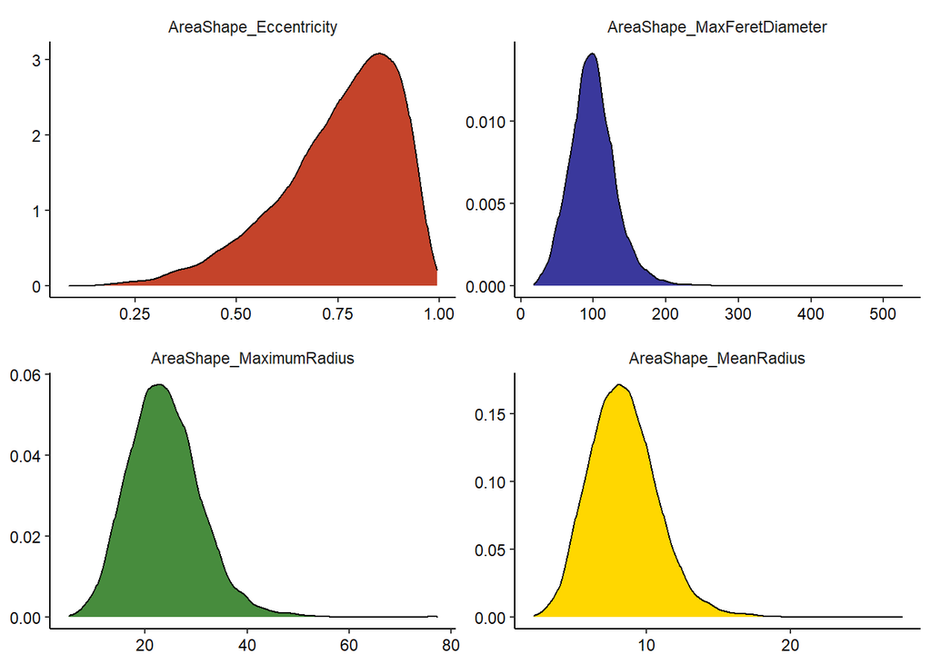

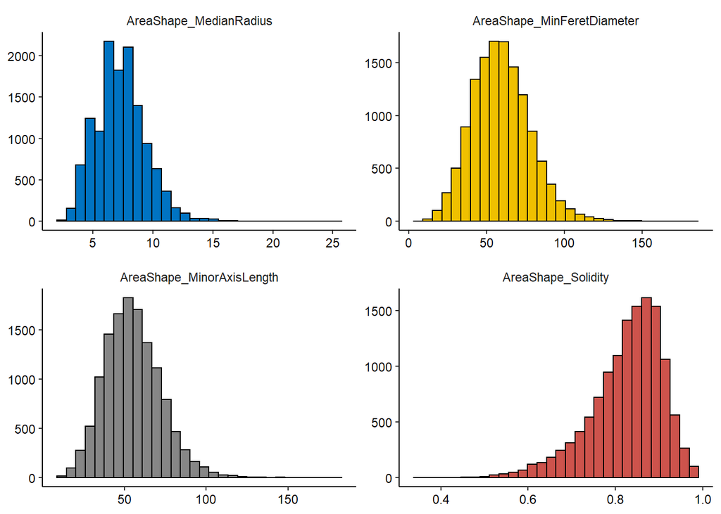

Figure 2.1 Basic densityplots and histograms.

```r
# basic densityplot
plotDensityplot(object, variables = vars_of_interest[1:4])

# plot histogram
plotHistogram(object, variables = vars_of_interest[5:8], clrp = "jco")
```

Both functions can be used in a comparative manner by specifying a grouping variable via the `across` argument.

```r
getGroupingVariableNames(object)
```

**output**

```
## [1] "cell_line"        "condition"        "concentration"    "moa"              "well_plate_name"  "well_plate_index"
## [7] "well"             "well_image"
```

```r
getGroupNames(object, grouping_variable = "condition")
```

**output**

```
##  [1] "5-fluorouracil"           "AG-1478"                  "anisomycin"               "AZ258"
##  [5] "caspase inhibitor (ZVAD)" "cyclohexamide"            "DMSO"                     "indirubin monoxime"
##  [9] "mitomycin C"              "neomycin"                 "olomoucine"               "taxol"
## [13] "tunicamycin"
```

```r
conds_of_interest <- c("DMSO", "5-fluorouracil", "taxol", "tunicamycin")
```

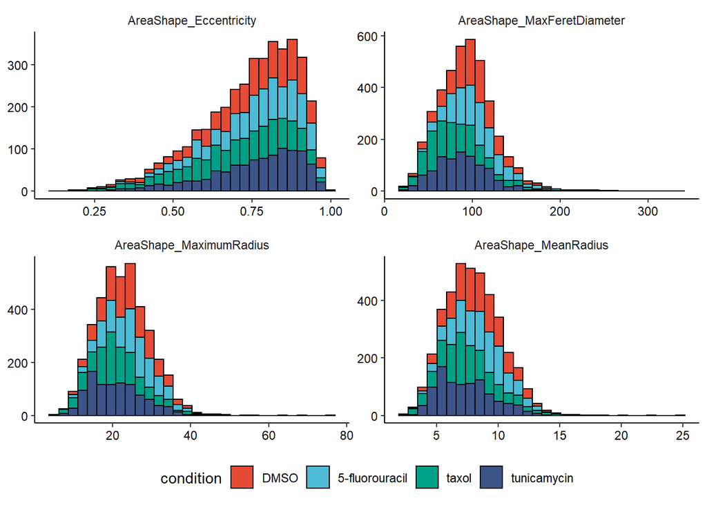

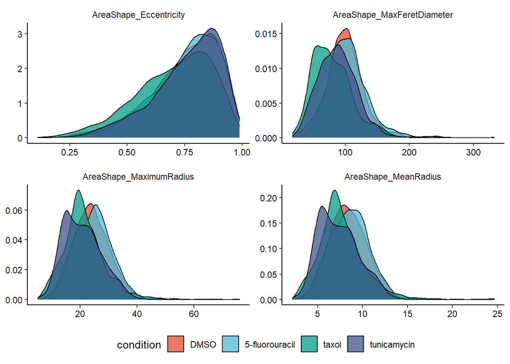

Figure 2.2 Distributions across a condition, suboptimal choice of plots

```r
# histograms are not suited for comparative plotting
plotHistogram(object,
                variable = vars_of_interest[1:4],
                across = "condition",
                across_subset = conds_of_interest,
                relevel = TRUE,
                clrp = "npg" # change colorpanel as color now refers to groups
                ) + legendBottom()

# densityplots have their drawbacks, too
plotDensityplot(object,
                variable = vars_of_interest[1:4],
                across = "condition",
                across_subset = conds_of_interest,
                relevel = TRUE,
                clrp = "npg", # change colorpanel as color now refers to groups
                alpha = 0.75 # increase transperancy
                ) + legendBottom()
```

### 2.2 Ridgeplots

To plot continuous variables in a comparative manner while using the style of densityplots we recommend ridgeplots, accesible through the function `plotRidgeplot()`.

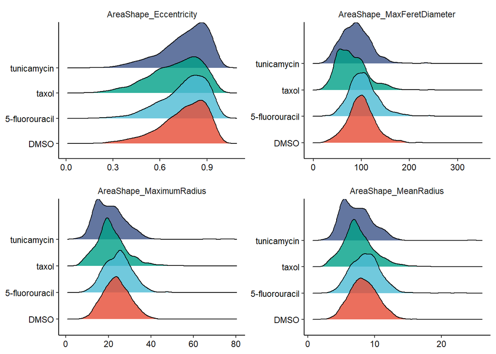

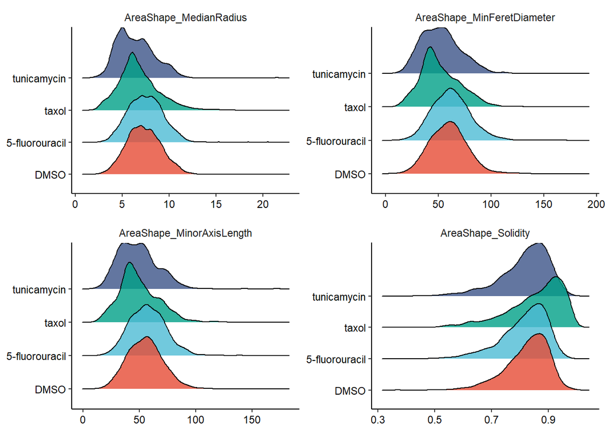

Figure 2.3 Ridgplots to compare across cell groups

```r
# first four vars
plotRidgeplot(object,
              variable = vars_of_interest[1:4],
              across = "condition",
              across_subset = conds_of_interest,
              relevel = TRUE,
              clrp = "npg") + legendNone()

# last four vars
plotRidgeplot(object,
              variable = vars_of_interest[5:8],
              across = "condition",
              across_subset = conds_of_interest,
              relevel = TRUE,
              clrp = "npg") + legendNone()
```

### 2.3 Boxplots and Violinplots

Each plot comes with its own respective function, namely `plotBoxplot()` and `plotViolinplot()`.

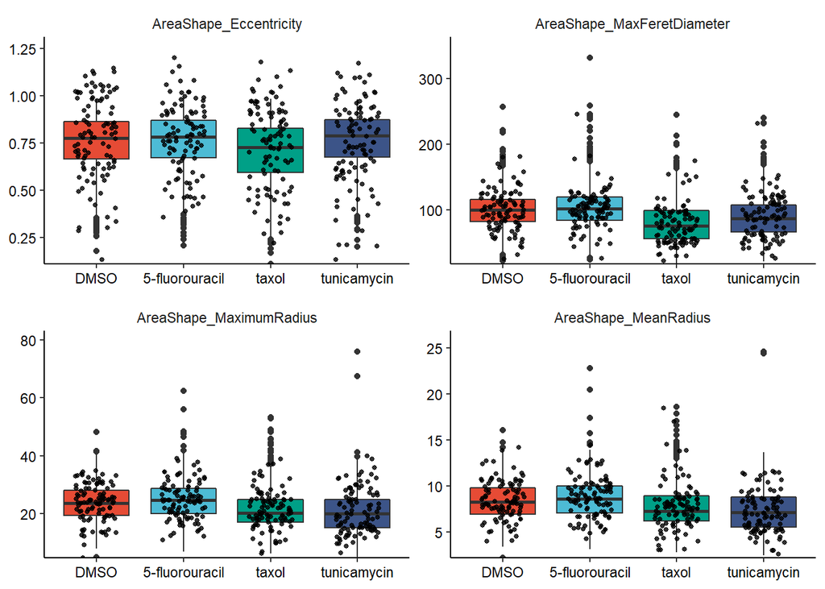

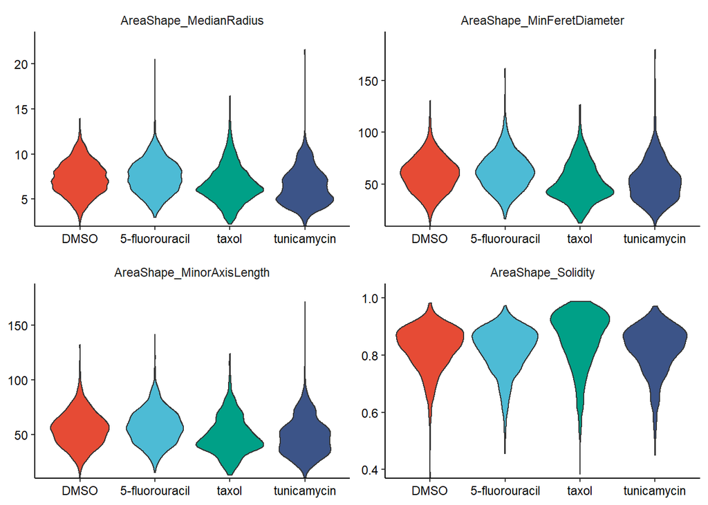

Figure 2.4 Boxplots and violinplots

```r
# first four vars
plotBoxplot(object,
            variable = vars_of_interest[1:4],
            across = "condition",
            across_subset = conds_of_interest,
            relevel = TRUE,
            display_points = TRUE,
            pt_size = 1,
            pt_shape = 19,
            clrp = "npg") + legendNone()

# last four vars
plotViolinplot(object,
               variable = vars_of_interest[5:8],
               across = "condition",
               across_subset = conds_of_interest,
               relevel = TRUE,
               clrp = "npg") + legendNone()
```

Statistical tests can either be performed pairwise (e.g. *t-test*) or groupwise (e.g. *anova*). The respective arguments are named accordingly.

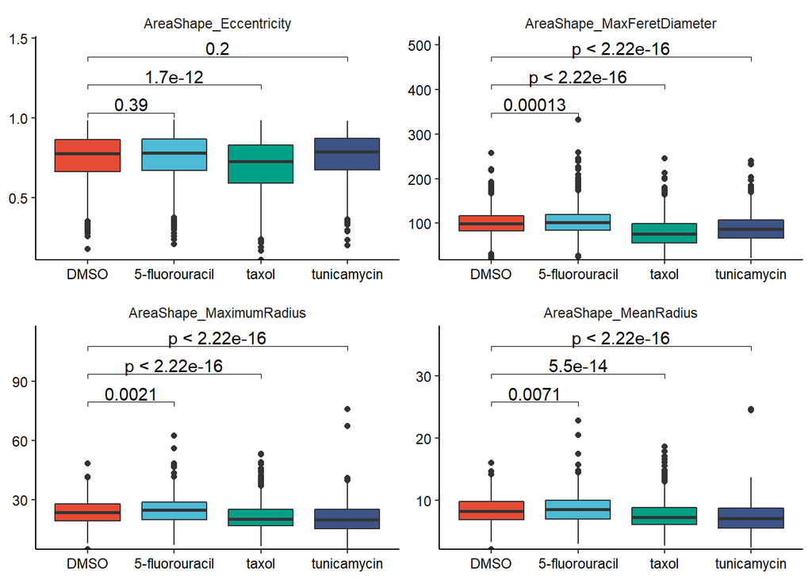

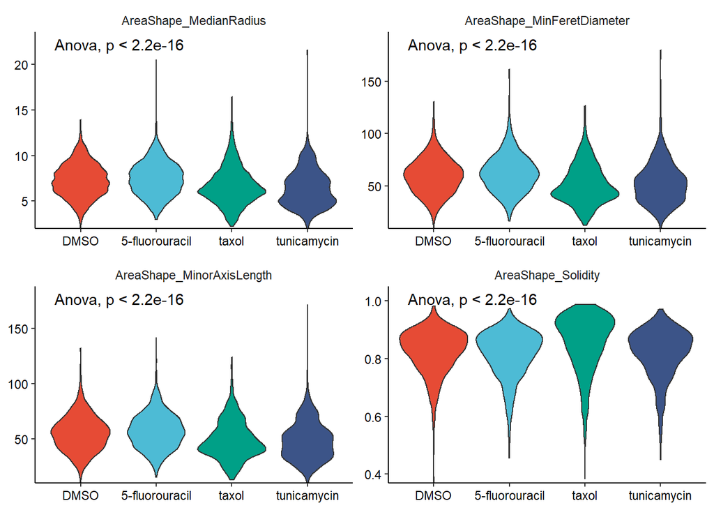

Figure 2.5 Boxplots and violinplots with t-test and anova.

```r
# first four vars
plotBoxplot(object,
            variable = vars_of_interest[1:4],
            across = "condition",
            across_subset = conds_of_interest,
            test_pairwise = "t.test",
            ref_group = "DMSO",
            step_increase = 0.2, # adjust the p-value bar hight
            clrp = "npg") + legendNone()

# last four vars
plotViolinplot(object,
               variable = vars_of_interest[5:8],
               across = "condition",
               across_subset = conds_of_interest,
               test_groupwise = "anova",
               clrp = "npg") + legendNone()
```

## 3. Caterogical variables

(coming soon)

## 4. Interactive plotting

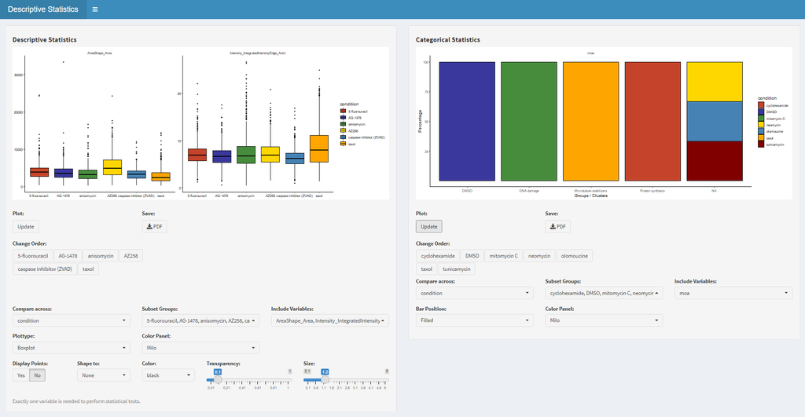

4.1 Interface of plotStatisticsInteractive()

```r
ploStatisticsInteractive(object)
```